# **COS80023 Big Data**

## **H/HD Project Report**

#### Viet Hoang Lai - 104350042

#### Semester 2 - 2023

#### Swinburne University of Technology

# **Part 1: EDA and Model Selection**

## **Introduction**

This report is the first part of final assessment for Swinburne University of Technology, COS80023 Big Data. This report embarks on a journey starting from data preprocessing, where the data is cleansed and prepared for analysis, followed by exploratory data analysis to uncover underlying structures and relationships. Hypothesis tests are conducted to validate assumptions about diamond prices based on their characteristics. Subsequently, the report delves into machine learning to predict diamond prices, employing models such as Linear Regression, XGBoost, and Random Forest. The performance of these models is meticulously evaluated to ensure the reliability of the predictions.

The detail of the second part (Model Deployment) will be detailed in the Report and Github (Link will be provided at the end of the Notebook).

[figure not shown]

[Source: OUTLOOK Planet](https://planet.outlookindia.com/opinions/lab-diamonds-are-good-for-the-pocket-and-the-planet-news-414962)

```python
# Load libraries
import numpy as np
import pandas as pd
import matplotlib.pyplot as plt
import seaborn as sns
from scipy import stats
import statsmodels.api as sm
from statsmodels.formula.api import ols
from sklearn.model_selection import train_test_split
from sklearn.metrics import mean_absolute_error, mean_squared_error, r2_score
from sklearn.compose import ColumnTransformer
from sklearn.preprocessing import OneHotEncoder, StandardScaler #Transfer
from sklearn.linear_model import LinearRegression
from sklearn.ensemble import RandomForestRegressor
import xgboost as xgb
```

## **Data Preprocessing & Explaination**

```python
# Load the dataset
diamonds_df = pd.read_csv("diamonds_dataset.csv")
# Check the dataset generally
diamonds_df.head()
```

|  | id | url | shape | price | carat | cut | color | clarity | report | type | date_fetched |
| --- | --- | --- | --- | --- | --- | --- | --- | --- | --- | --- | --- |
| 0 | 10086429 | https://www.brilliantearth.com//loose-diamonds... | Round | 400 | 0.30 | Very Good | J | SI2 | GIA | natural | 2020-11-29 12-26 PM |
| 1 | 10016334 | https://www.brilliantearth.com//loose-diamonds... | Emerald | 400 | 0.31 | Ideal | I | SI1 | GIA | natural | 2020-11-29 12-26 PM |
| 2 | 9947216 | https://www.brilliantearth.com//loose-diamonds... | Emerald | 400 | 0.30 | Ideal | I | VS2 | GIA | natural | 2020-11-29 12-26 PM |
| 3 | 10083437 | https://www.brilliantearth.com//loose-diamonds... | Round | 400 | 0.30 | Ideal | I | SI2 | GIA | natural | 2020-11-29 12-26 PM |
| 4 | 9946136 | https://www.brilliantearth.com//loose-diamonds... | Emerald | 400 | 0.30 | Ideal | I | SI1 | GIA | natural | 2020-11-29 12-26 PM |

```python
diamonds_df.info()
```

```
<class 'pandas.core.frame.DataFrame'>
RangeIndex: 119307 entries, 0 to 119306
Data columns (total 11 columns):
 #   Column        Non-Null Count   Dtype
---  ------        --------------   -----
 0   id            119307 non-null  int64
 1   url           119307 non-null  object
 2   shape         119307 non-null  object
 3   price         119307 non-null  int64
 4   carat         119307 non-null  float64
 5   cut           119307 non-null  object
 6   color         119307 non-null  object
 7   clarity       119307 non-null  object
 8   report        119307 non-null  object
 9   type          119307 non-null  object
 10  date_fetched  119307 non-null  object
dtypes: float64(1), int64(2), object(8)
memory usage: 10.0+ MB
```

[figure not shown]

```python
diamonds_df['shape'].unique()
```

```
array(['Round', 'Emerald', 'Marquise', 'Princess', 'Pear', 'Heart',
       'Oval', 'Cushion', 'Asscher', 'Radiant'], dtype=object)
```

[figure not shown]

[Source: CARATLANE](https://www.caratlane.com/blog/laymans-guide-to-diamond-shapes/)

**Shape** columns has 10 unique values: Round, Emerald, Marquise, Princess, Pear, Heart, Oval, Cushion, Asscher, Radiant; Different shapes may have different prices

```python
diamonds_df['carat'].describe()
```

```
count    119307.000000
mean          0.884169
std           0.671141
min           0.250000
25%           0.400000
50%           0.700000
75%           1.100000
max          15.320000
Name: carat, dtype: float64
```

[figure not shown]

[Source: ZAVANDI](https://zavandi.com/pages/diamond-carat)

```python
diamonds_df['cut'].unique()
```

```
array(['Very Good', 'Ideal', 'Super Ideal', 'Good', 'Fair'], dtype=object)
```

[figure not shown]

[Source: Diamond Exchange](https://diamondexchange.com.au/pages/diamond-cut)

The dataset includes diamonds of varying cut grades: 'Very Good', 'Ideal', 'Super Ideal', 'Good', and 'Fair'. The visual showing that 'Super Ideal' cut diamonds have the most precise dimensions for optimal light emission, while 'Good' and 'Fair' are not offered by Diamond Exchange due to their lower light reflection. This detailed classification aids in understanding the quality and value of diamonds in the dataset.

```python
diamonds_df['color'].unique()
```

```
array(['J', 'I', 'E', 'F', 'G', 'H', 'D'], dtype=object)
```

[figure not shown]

[Source: Australian Diamond Network](https://www.australiandiamondnetwork.com.au/pages/diamond-colour)

**Colour** shows a range of color from D to J while D is colorless and getting more yellow to J

```python
diamonds_df['clarity'].unique()
```

```
array(['SI2', 'SI1', 'VS2', 'VVS1', 'VS1', 'VVS2', 'IF', 'FL'],
      dtype=object)
```

[figure not shown]

[Source: Vrai](https://www.vrai.com/journal/post/diamond-clarity-chart)

**Clarity** represents the clarity grades of diamonds in the dataset, ranging from included (SI1, SI2), very slightly included (VS1, VS2), very very slightly included (VVS1, VVS2), to the rarest and most pure forms, internally flawless (IF) and flawless (FL). These grades indicate the level of imperfections or inclusions in the diamonds, with FL being completely free of inclusions even under 10x magnification, and SI grades containing inclusions that are noticeable under magnification. These clarity levels are critical for evaluating diamond quality and value.

```python
diamonds_df['report'].unique()
```

```
array(['GIA', 'HRD', 'IGI', 'GCAL'], dtype=object)
```

- **GIA**: Gemological Institute of America, known for its strict grading standards.
- **HRD**: Hoge Raad voor Diamant (Diamond High Council), based in Antwerp, known for high-quality diamond certification.
- **IGI**: International Gemological Institute, provides a wide range of services including grading for diamonds of all sizes.
- **GCAL**: Gem Certification and Assurance Lab, known for its guarantee on diamond grading. Each report provides a professional assessment of the diamonds' characteristics such as cut, color, clarity, and carat weight.

```python
diamonds_df['type'].unique()
```

```
array(['natural', 'lab'], dtype=object)
```

[figure not shown]

[Source: JPratt Designs](https://www.jprattdesigns.com/blog/7-reasons-choose-real-diamonds-vs-lab-created-diamonds/)

**Type** represents two categories of diamonds included in the dataset: 'natural' and 'lab'.

- **Natural diamonds** are those formed over billions of years in the Earth's mantle under natural geological processes.
- **Lab-created**, or synthetic, diamonds are grown in controlled laboratory environments using technological processes that replicate the conditions under which natural diamonds develop.

Both types of diamonds possess identical chemical and physical properties, but their origins are distinctly different.

```python
# Check for missing values
missing_values = diamonds_df.isnull().sum()
missing_values
```

```
id              0
url             0
shape           0
price           0
carat           0
cut             0
color           0
clarity         0
report          0
type            0
date_fetched    0
dtype: int64
```

```python
# Check for duplicate rows
duplicate_rows = diamonds_df[diamonds_df.duplicated()]
# Count the number of duplicate rows
num_duplicates = duplicate_rows.shape[0]
# Show the number of duplicates
num_duplicates
```

```
0
```

```python
# Drop unnecessary columns
diamonds_df = diamonds_df.drop(columns=['id', 'url', 'date_fetched'])
```

## **Exploratory Data Analysis (EDA)**

### 1, Visualize and Calculate Distribution of Diamond Prices

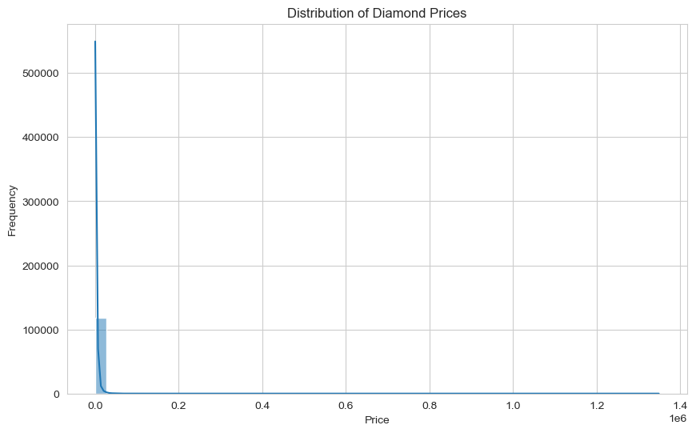

```
count      119,307.00
mean         3,286.84
std          9,114.70
min            270.00
25%            900.00
50%          1,770.00
75%          3,490.00
max      1,348,720.00
Name: price, dtype: object
```

```python
sns.set_style("whitegrid")
# Plot the distribution of the target variable 'price'
plt.figure(figsize=(10, 6))
sns.histplot(diamonds_df['price'], bins=50, kde=True)
plt.title('Distribution of Diamond Prices')
plt.xlabel('Price')
plt.ylabel('Frequency')
plt.show()
# Display basic statistics for the 'price' column
price_statistics = diamonds_df['price'].describe()
price_stats = price_statistics.apply(lambda x: f"{x:,.2f}")
price_stats
```

The histogram of diamond prices showcases a highly skewed distribution, indicative of the presence of significant outliers. With a dataset of 119,307 diamonds, the average price stands at $3,286.84, though the standard deviation is substantial at $9,114.70, reflecting wide price variability. The minimum diamond price recorded is $270, and prices are as low as $900 for the 25th percentile, climbing to $1,770 by the median, and $3,490 by the 75th percentile. Notably, the maximum price of a diamond in this dataset is an exceptional $1,348,720, which underscores the existence of extreme outliers significantly distorting the overall distribution.

### 2, Box Plot for Carat

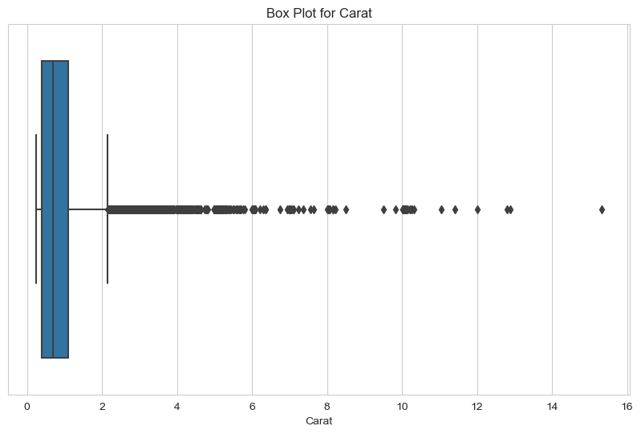

```
count    119,307.00
mean           0.88
std            0.67
min            0.25
25%            0.40
50%            0.70
75%            1.10
max           15.32
Name: carat, dtype: object
```

```python
plt.figure(figsize=(10, 6))
sns.boxplot(x=diamonds_df['carat'])
plt.title('Box Plot for Carat')
plt.xlabel('Carat')
plt.show()
carat_statistics = diamonds_df['carat'].describe()
carat_stats = carat_statistics.apply(lambda x: f"{x:,.2f}")
carat_stats
```

The box plot visualizing carat weight of diamonds reveals a concentrated distribution with a mean of 0.88 carats and a standard deviation of 0.67, indicating moderate spread around the average. The data, spanning 119,307 observations, has a minimum carat of 0.25 and shows a median (50th percentile) at 0.70 carats, demonstrating that half of the diamonds are below this weight. The 25th and 75th percentiles are at 0.40 and 1.10 carats, respectively. Notably, there is a significant number of outliers, as seen by individual points beyond the upper whisker, with the maximum carat size reaching 15.32, which is quite distant from the main cluster of data.

### 3, Distribution of Shape, Cut, Clarity, Report by Type

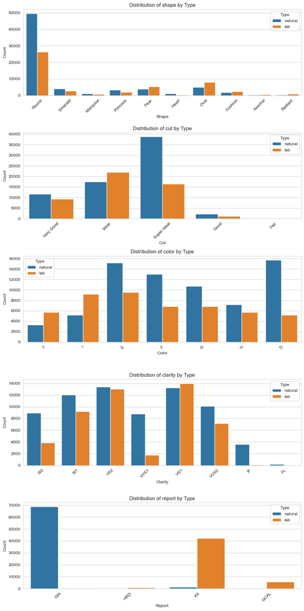

```python
# List of categorical columns to examine
categorical_columns = ['shape', 'cut', 'color', 'clarity', 'report']
# Plot the distribution of each categorical column for 'natural' and 'lab'
fig, axes = plt.subplots(nrows=len(categorical_columns), figsize=(10, 20))
for i, col in enumerate(categorical_columns):
    sns.countplot(data=diamonds_df, x=col, hue='type', ax=axes[i])
    axes[i].set_title(f'Distribution of {col} by Type')
    axes[i].set_ylabel('Count')
    axes[i].set_xlabel(col.capitalize())
    axes[i].tick_params(axis='x', rotation=45)
    axes[i].legend(title='Type')
plt.tight_layout()
plt.show()
```

### 4, Correlation between Price & Carat

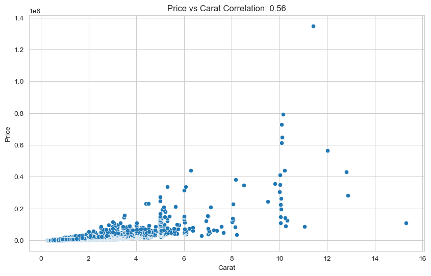

```
0.5555783947414691
```

```python
# Calculate the correlation between 'price' and 'carat'
price_carat_corr = diamonds_df[['price', 'carat']].corr().iloc[0, 1]
# Plot the scatterplot between 'price' and 'carat'
plt.figure(figsize=(10, 6))
sns.scatterplot(data=diamonds_df, x='carat', y='price')
plt.title(f'Price vs Carat Correlation: {price_carat_corr:.2f}')
plt.xlabel('Carat')
plt.ylabel('Price')
plt.show()
price_carat_corr
```

## **Hypothesis Testing**

#### 1, The average price of round shape diamonds vs all shape diamonds

Null Hypothesis (H0): All shape and type have same average price

```python
# Create separate DataFrames for each type of diamonds
all_types_df = diamonds_df
natural_df = diamonds_df[diamonds_df['type'] == 'natural']
lab_df = diamonds_df[diamonds_df['type'] == 'lab']
```

```python
def compare_average_prices(df, type_label):
    # Group by 'cut' and calculate the mean price for each group
    average_price_by_cut = df.groupby('shape')['price'].mean()
    # Perform a t-test between the group of 'Round' cut diamonds and all other cuts
    round_prices = df[df['shape'] == 'Round']['price']
    other_prices = df[df['shape'] != 'Round']['price']
    t_stat, p_value = stats.ttest_ind(round_prices, other_prices, equal_var=False, nan_policy='omit')
    # Sort the average prices from highest to lowest
    sorted_average_prices = average_price_by_cut.sort_values(ascending=False)
    # Print the results
    print(f"{type_label} - t-statistic: {t_stat}, p-value: {p_value}")
    print(f"{type_label} - Average prices from highest to lowest:")
    print(sorted_average_prices)
```

```python
# Compare for all types
compare_average_prices(all_types_df, 'All Types')
```

```
All Types - t-statistic: -14.038212030261608, p-value: 1.0648040505919015e-44
All Types - Average prices from highest to lowest:
shape
Asscher     7966.723077
Cushion     6622.783361
Radiant     5898.500000
Emerald     3964.291852
Oval        3940.499307
Princess    3855.004869
Heart       3507.714702
Round       2970.875000
Pear        2203.720855
Marquise    1884.655172
Name: price, dtype: float64
```

The statistical analysis comparing the average prices of round shape diamonds to all other shapes indicates that round diamonds have a lower average price than several other shapes. The average price for round diamonds is reported at $2,970.88, which is less than Asscher ($7,966.72), Cushion ($6,622.78), and even Radiant ($5,898.50) shaped diamonds. This result is supported by a t-statistic of -14.038212030261608 and an extremely low p-value of 1.0648040505919015e-44, which suggests that the difference in average prices is statistically significant and that round diamonds tend to be cheaper on average compared to other shapes

```python
# Compare for natural type
compare_average_prices(natural_df, 'Natural Type')
```

```
Natural Type - t-statistic: -10.846561417660475, p-value: 2.3766702456063296e-27
Natural Type - Average prices from highest to lowest:
shape
Asscher     12470.203252
Radiant      8417.324415
Cushion      7959.095745
Oval         4698.769015
Princess     3681.777570
Emerald      3570.410410
Heart        3290.708134
Pear         3138.038007
Round        2983.961018
Marquise     2006.327839
Name: price, dtype: float64
```

The significant t-statistic of -10.846561417660475 and the minuscule p-value of 2.3766702456063296e-27 strongly indicate that these differences in average prices are statistically significant.

```python
# Compare for lab type
compare_average_prices(lab_df, 'Lab Type')
```

```
Lab Type - t-statistic: -11.653205982683774, p-value: 2.4608433618995175e-31
Lab Type - Average prices from highest to lowest:
shape
Cushion     5575.568987
Asscher     5224.504950
Radiant     4958.264669
Emerald     4535.806100
Heart       4196.990881
Princess    4141.716649
Oval        3465.892007
Round       2946.272335
Marquise    1679.614198
Pear        1520.741506
Name: price, dtype: float64
```

The t-statistic of -11.653205982683774 and the very low p-value of 2.4608433618995175e-31 confirm the statistical significance of these differences in average prices among lab-created diamonds.

**To sum it up: Different shape and type of diamonds have different price**

#### 2, The average price differs by clarity grade

Null Hypothesis (H0): The average price doesn't differ by clarity grade

```python
# ANOVA
anova_results = ols('price ~ C(clarity)', data=diamonds_df).fit()
anova_table = sm.stats.anova_lm(anova_results, typ=2)
anova_table
```

|  | sum_sq | df | F | PR(>F) |
| --- | --- | --- | --- | --- |
| C(clarity) | 1.565286e+11 | 7.0 | 273.463293 | 0.0 |
| Residual | 9.755136e+12 | 119299.0 | NaN | NaN |

This p-value is so low it's approximated to zero, which in statistical terms indicates a very strong rejection of the null hypothesis that there is no difference in mean prices across different clarity categories.

#### 3, Check if the distribution of cut quality is different for diamonds of different colors

Null Hypothesis: The distribution of cut quality is not different for diamonds of different colors

```python
# Chi-Square Test
contingency_table = pd.crosstab(diamonds_df['cut'], diamonds_df['color'])
chi2_test_results = stats.chi2_contingency(contingency_table)
chi2_test_results
```

```
(1803.0640859238254,
 0.0,
 24,
 array([[   58.49836137,    69.23164609,    55.52249239,    49.15642837,
            36.02397177,    40.33800196,    25.22909804],
        [  595.14201178,   704.33872279,   564.86655435,   500.10042998,
           366.49537747,   410.38482235,   256.67208127],
        [ 6903.68236566,  8170.37064045,  6552.48527748,  5801.19442279,
          4251.36794991,  4760.48809374,  2977.41124997],
        [ 9675.69902856, 11450.99717535,  9183.4867359 ,  8130.53212301,
          5958.40807329,  6671.95383339,  4172.9230305 ],
        [ 3662.97823263,  4335.06181532,  3476.63893988,  3078.01659584,
          2255.70462756,  2525.83524856,  1579.76454022]]))
```

The Chi-Square test results reveal a highly significant association between the cut and color of diamonds. The Chi-Square statistic is 1803.064, with a p-value effectively at 0, and 24 degrees of freedom. These results suggest that there is a statistically significant relationship between the cut quality and color of the diamonds in the dataset, meaning that the distribution of colors is not uniform across different cuts.

## **Machine Learning**

### 1, Preprocessing

#### a, Remove outlier

```python
# Define the conditions for rows to be removed
conditions = (diamonds_df['carat'] > 8) | (diamonds_df['price'] > 30000)

# Filter out the rows that meet the conditions
diamonds_df = diamonds_df[~conditions]
```

Diamonds exceeding 8 carats were considered outliers due to their rarity and the significant impact they have on the overall price distribution. Similarly, diamonds priced over $30,000 were removed as they represent a segment of the market that is not typical of the average consumer experience and could skew the analysis towards these high-value transactions.

#### b, Split data for train/test

```python
# Split the dataset into training and testing sets
train_df, test_df = train_test_split(diamonds_df, test_size=0.2, random_state=42)
# Separate the target variable 'price' from the features
X_train = train_df.drop(columns='price')
y_train = train_df['price']
X_test = test_df.drop(columns='price')
y_test = test_df['price']
X_train.shape, X_test.shape
```

```
((94910, 7), (23728, 7))
```

#### c, Transform the dataset to fit model

```python
# Define the columns to be encoded and scaled
categorical_features = ['shape', 'cut', 'color', 'clarity', 'report', 'type']
numerical_features = ['carat']
# Create a column transformer
preprocessor = ColumnTransformer(
    transformers=[
        ('num', StandardScaler(), numerical_features),
        ('cat', OneHotEncoder(drop='first'), categorical_features)
    ])
# Fit the preprocessor on the training data and transform both training and testing data
X_train_preprocessed = preprocessor.fit_transform(X_train)
X_test_preprocessed = preprocessor.transform(X_test)
X_train_preprocessed.shape, X_test_preprocessed.shape
```

```
((94910, 31), (23728, 31))
```

### 2, Linear Regression Model

#### a, Train model

```python
# Initialize and train the linear regression model
lr_model = LinearRegression()
lr_model.fit(X_train_preprocessed, y_train)
# Predict on the testing set
y_pred = lr_model.predict(X_test_preprocessed)
# Calculate performance metrics
mse = mean_squared_error(y_test, y_pred)
mae = mean_absolute_error(y_test, y_pred)
rmse = mean_squared_error(y_test, y_pred, squared=False)  # squared=False gives RMSE
r2 = r2_score(y_test, y_pred)
mse, mae, rmse, r2
```

```
(2706599.2340739, 1051.6922973768285, 1645.1745299736135, 0.7874145733411692)
```

The linear regression model's performance on predicting diamond prices shows an average error of $1,051.69 with an error spread of $1,645.17. The model explains approximately 78.74% of the variance in diamond prices, indicating a good predictive ability.

#### b, Visualize predict vs actual values

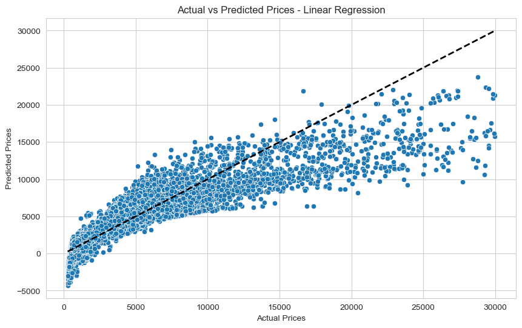

```python
# Corrected scatter plot for predicted vs actual values
plt.figure(figsize=(10, 6))
sns.scatterplot(x=y_test, y=y_pred)  # Specify x and y explicitly
plt.plot([y_test.min(), y_test.max()], [y_test.min(), y_test.max()], 'k--', lw=2)  # Diagonal line for reference
plt.xlabel('Actual Prices')
plt.ylabel('Predicted Prices')
plt.title('Actual vs Predicted Prices - Linear Regression')
plt.show()
```

Most points cluster around the line of perfect prediction (dashed line), but the spread increases with higher prices, indicating greater prediction errors in that range. This pattern is consistent with the performance metrics provided earlier, suggesting the model predicts lower-priced diamonds more accurately than higher-priced ones.

### 3, XGB Model

#### a, Train model

```python
# Initialize the XGBoost regressor
xgb_model = xgb.XGBRegressor(objective='reg:squarederror', n_estimators=100, random_state=42)
# Train the model
xgb_model.fit(X_train_preprocessed, y_train)
# Predict on the testing set
y_pred_xgb = xgb_model.predict(X_test_preprocessed)
# Calculate performance metrics
mse_xgb = mean_squared_error(y_test, y_pred_xgb)
mae_xgb = mean_absolute_error(y_test, y_pred_xgb)
rmse_xgb = mean_squared_error(y_test, y_pred_xgb, squared=False)
r2_xgb = r2_score(y_test, y_pred_xgb)
mse_xgb, mae_xgb, rmse_xgb, r2_xgb
```

```
(311068.86964533286, 227.18033830482898, 557.7354835810008, 0.9755676024949219)
```

Comparing with Linear Regression model, XGBoost model shows higher accuracy in predicting diamond prices with an R-squared value of 0.976, indicating it explains 97.6% of the variance. The errors—Mean Absolute Error (MAE) of 227.18 and Root Mean Squared Error (RMSE) of 557.74—are relatively low, suggesting strong predictive performance.

#### b, Visualize predict vs actual values

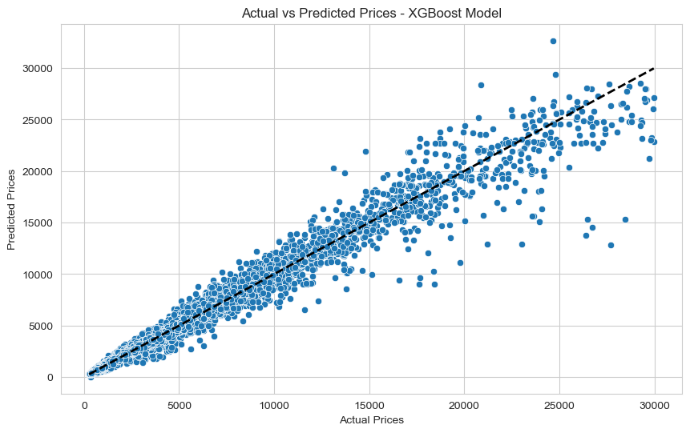

```python
# Corrected scatter plot for predicted vs actual values
plt.figure(figsize=(10, 6))
sns.scatterplot(x=y_test, y=y_pred_xgb)  # Specify x and y explicitly
plt.plot([y_test.min(), y_test.max()], [y_test.min(), y_test.max()], 'k--', lw=2)  # Diagonal line for reference
plt.xlabel('Actual Prices')
plt.ylabel('Predicted Prices')
plt.title('Actual vs Predicted Prices - XGBoost Model')
plt.show()
```

#### c, Features Importance in XGB model

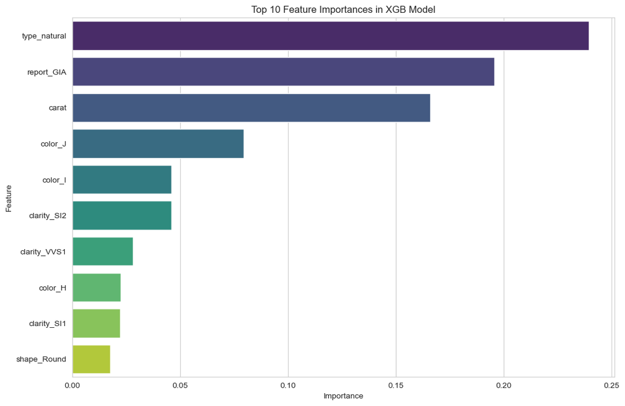

```python
categorical_features = ['shape', 'cut', 'color', 'clarity', 'report', 'type']
numerical_features = ['carat']

feature_names = (numerical_features +
                 list(preprocessor.named_transformers_['cat'].get_feature_names_out(input_features=categorical_features)))
feature_importances = xgb_model.feature_importances_
importance_df = pd.DataFrame({
    'Feature': feature_names,
    'Importance': feature_importances
})
# Sort the DataFrame by importance in descending order
importance_df = importance_df.sort_values(by='Importance', ascending=False)
# Visualize the top 10 most important features
plt.figure(figsize=(12, 8))
sns.barplot(x='Importance', y='Feature', data=importance_df.head(10), palette='viridis')
plt.title('Top 10 Feature Importances in XGB Model')
plt.xlabel('Importance')
plt.ylabel('Feature')
plt.show()
```

'Type_natural' and 'report_GIA' are the most influential, followed by 'carat', which is a key determinant of a diamond's value. Color features, particularly 'color_J', 'color_I', and 'color_H', also play significant roles, as do clarity grades 'clarity_SI2', 'clarity_VVS1', and 'clarity_SI1'. The 'shape_Round' feature appears as well, indicating its specific impact compared to other shapes. This chart highlights the factors that the model finds most predictive of diamond prices.

### 4, RandomForest Model

#### a, Train model

```python
# Initialize the Random Forest regressor
rf_model = RandomForestRegressor(n_estimators=100, random_state=42)
# Train the model
rf_model.fit(X_train_preprocessed, y_train)
# Predict on the testing set
y_pred_rf = rf_model.predict(X_test_preprocessed)
# Calculate performance metrics
mse_rf = mean_squared_error(y_test, y_pred_rf)
mae_rf = mean_absolute_error(y_test,y_pred_rf)
rmse_rf = mean_squared_error(y_test, y_pred_rf, squared=False)
r2_rf = r2_score(y_test, y_pred_rf)
mse_rf, mae_rf, rmse_rf, r2_rf
```

```
(261402.41009116522, 202.55141912448332, 511.2752781928393, 0.979468573633181)
```

The Random Forest model shows a high R-squared of 0.979, indicating it explains 97.9% of the variance in prices, with a low Mean Absolute Error of about 202.55, suggesting accurate predictions. A little bit better than XGB model.

#### b, Visualize predict vs actual values

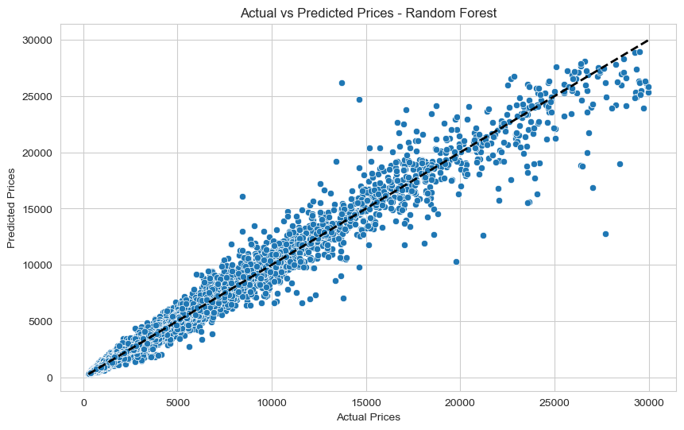

```python
# Corrected scatter plot for predicted vs actual values
plt.figure(figsize=(10, 6))
sns.scatterplot(x=y_test, y=y_pred_rf)
plt.plot([y_test.min(), y_test.max()], [y_test.min(), y_test.max()], 'k--', lw=2)  # Diagonal line for reference
plt.xlabel('Actual Prices')
plt.ylabel('Predicted Prices')
plt.title('Actual vs Predicted Prices - Random Forest')
plt.show()
```

The data points cluster tightly along the line of perfect prediction, indicating that the model has a high accuracy rate, especially for diamonds in the lower to mid-price ranges. As the price increases, there is some divergence, suggesting slight discrepancies in the model's predictions for higher-valued diamonds.

#### c, Features Importance in RandomForest model

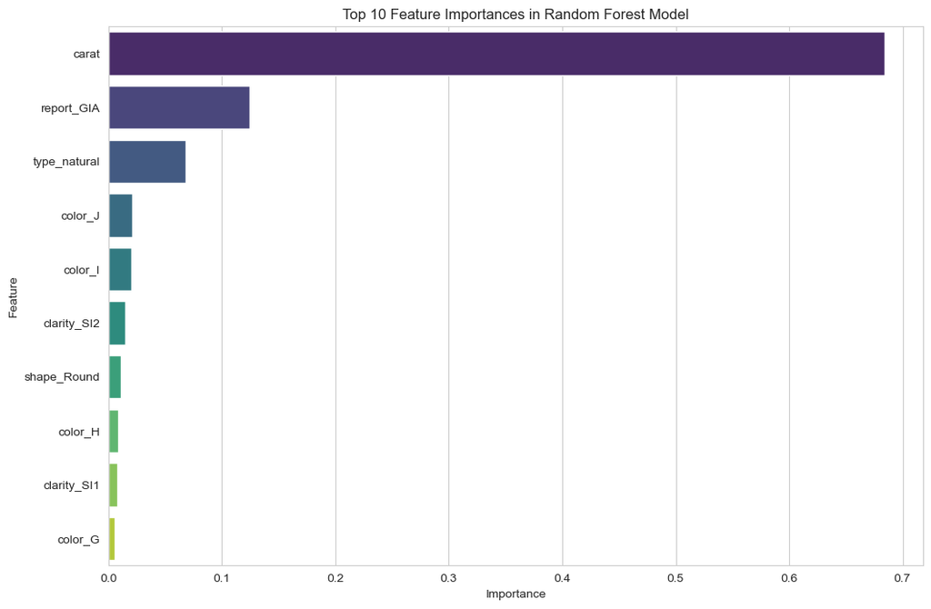

```python
feature_importances = rf_model.feature_importances_
importance_df = pd.DataFrame({
    'Feature': feature_names,
    'Importance': feature_importances
})
# Sort the DataFrame by importance in descending order
importance_df = importance_df.sort_values(by='Importance', ascending=False)
# Visualize the top 10 most important features
plt.figure(figsize=(12, 8))
sns.barplot(x='Importance', y='Feature', data=importance_df.head(10), palette='viridis')
plt.title('Top 10 Feature Importances in Random Forest Model')
plt.xlabel('Importance')
plt.ylabel('Feature')
plt.show()
```

'Carat' weight is the most significant predictor, followed by the 'report_GIA' certification and whether the diamond is 'type_natural' or lab-created. Color grades 'color_J', 'color_I', and 'color_H' also contribute to price prediction, along with clarity grades 'clarity_SI2' and 'clarity_SI1'. The 'shape_Round' is another important feature, reflecting its influence on a diamond's value.

### 4, Model Comparison

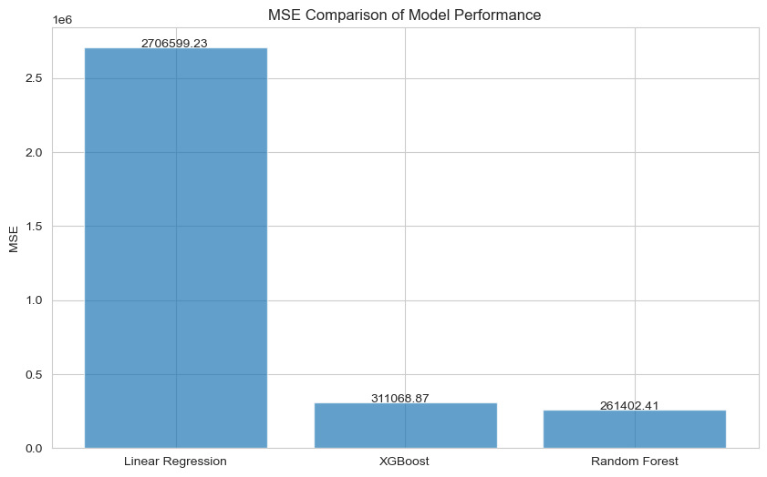

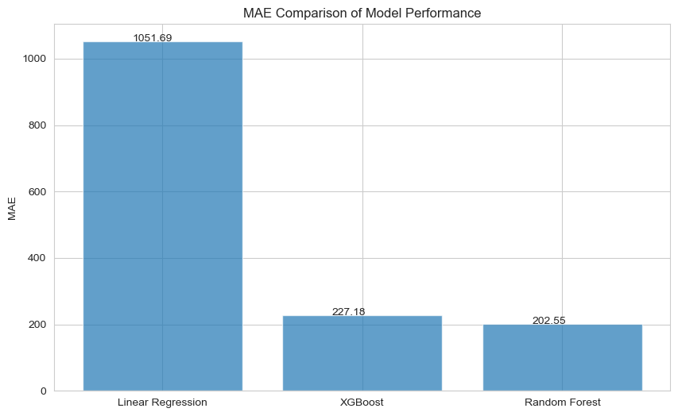

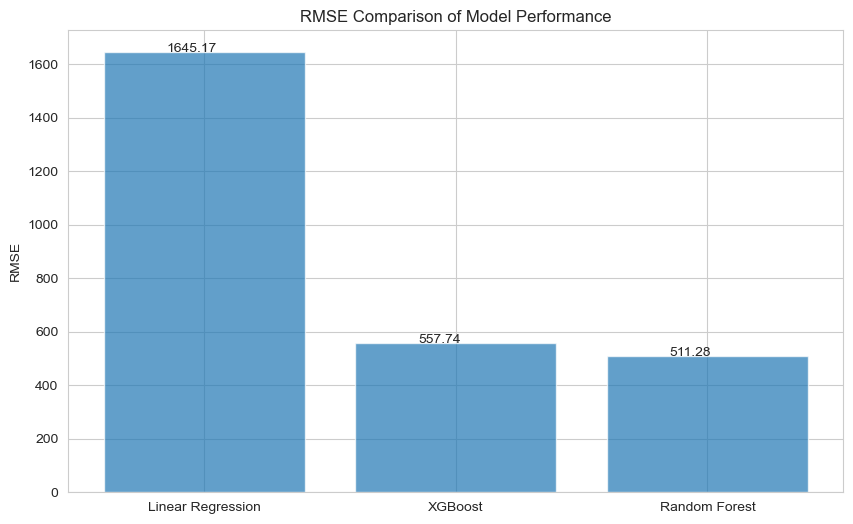

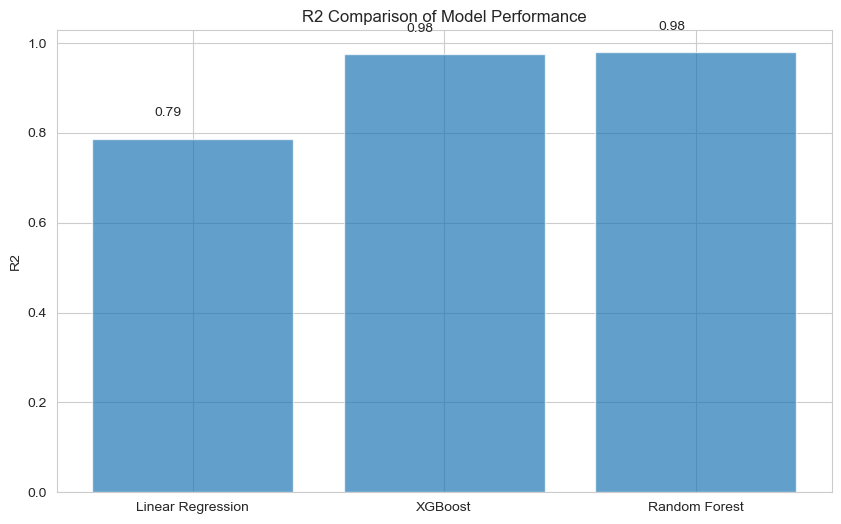

```python
mse_values = [mse, mse_xgb, mse_rf]
mae_values = [mae, mae_xgb, mae_rf]
rmse_values = [rmse, rmse_xgb, rmse_rf]
r2_values = [r2, r2_xgb, r2_rf]
model_names = ['Linear Regression', 'XGBoost', 'Random Forest']
def create_bar_chart(metric_values, metric_name, model_names):
    plt.figure(figsize=(10, 6))
    y_pos = np.arange(len(model_names))
    plt.bar(y_pos, metric_values, align='center', alpha=0.7)
    plt.xticks(y_pos, model_names)
    plt.ylabel(metric_name)
    plt.title(f'{metric_name} Comparison of Model Performance')
    for i in range(len(y_pos)):
        plt.text(x = y_pos[i]-0.15 , y = metric_values[i]+0.05, s = round(metric_values[i], 2), size = 10)
    plt.show()
# Create bar charts for each metric
create_bar_chart(mse_values, 'MSE', model_names)
create_bar_chart(mae_values, 'MAE', model_names)
create_bar_chart(rmse_values, 'RMSE', model_names)
create_bar_chart(r2_values, 'R2', model_names)
```

- **MSE Chart:** Lower is better. Shows Random Forest with the lowest MSE, indicating the smallest difference on average between the predicted and actual values.
- **MAE Chart:** Lower is better. Shows Random Forest with the lowest MAE, indicating more accurate predictions on average.
- **RMSE Chart:** Lower is better. Random Forest again shows the lowest RMSE, suggesting it has the least variance in its error.
- **R² Chart:** Higher is better. Close to 1 is ideal. Both XGBoost and Random Forest models show very high R², indicating a strong ability to explain the variance in the data.

In conclusion, after evaluating the performance of Linear Regression, XGBoost, and Random Forest models through various metrics such as MSE, MAE, RMSE, and R², the Random Forest model emerged as the most effective for predicting diamond prices. With the lowest MSE and MAE and a high R² value, it demonstrates superior accuracy and consistency. Consequently, the Random Forest model has been chosen for deployment due to its robust predictive capabilities and its potential to provide reliable price estimates in a production environment.

# **Part 2: Model Deployment**

Link to Model Deployment: [Diamond-Prediction](https://github.com/NotReallyDark9/diamond-prediction)